# re_airquality

Valentin Lanz

2025-03-10

The goal of this exercise is to analyse correlations of different variables and visualize them using the ggplot2 library.

## Description of the airquality dataset

The airquality dataset is a built-in dataset in R that shows the air quality in New York measured daily from May to September 1973. The data sources are the New York State Department of Conservation and the National Weather Service. The dataset features the following variables:

[,1] Ozone  
[,2] Solar.R  
[,3] Wind  
[,4] Temp  
[,5] Month  
[,6] Day

Ozone: Mean ozone in parts per billion from 1300 to 1500 hours at Roosevelt Island

Solar.R: Solar radiation in Langleys in the frequency band 4000–7700 Angstroms from 0800 to 1200 hours at Central Park

Wind: Average wind speed in miles per hour at 0700 and 1000 hours at LaGuardia Airport

Temp: Maximum daily temperature in degrees Fahrenheit at La Guardia Airport.

Month: Numeric value indicating the month of measurement. Ranges from 1 to 12.

Day: Numeric value indicating the day of measurement. Ranges from 1 to 31.

## Research question

I want to investigate how ozone concentration is influenced by the variables wind, solar radiation and temperature.  
To get an idea of the data set, i will first plot the ozone concentration value of each day.

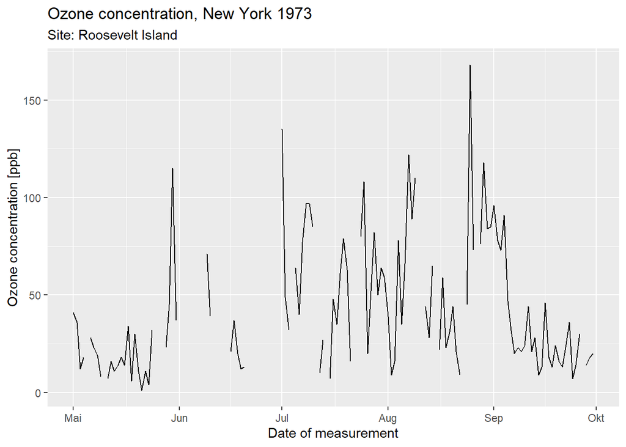

```r
library(ggplot2)
library(readr)
library(lubridate)
library(dplyr)
library(tidyverse)

airquality <- datasets::airquality

#add a column with the measurement date
airquality <- airquality |> dplyr::mutate(
   measurement_date = ymd(paste(1973, Month, Day)))

#plot ozone concentration over time
ggplot(data = airquality, aes(x = measurement_date, y = Ozone)) +
  geom_line() +
  labs(title = "Ozone concentration, New York 1973",
       subtitle = "Site: Roosevelt Island",
       x = "Date of measurement",
       y = "Ozone concentration [ppb]")
```

As we see, there are values missing for certain days, which causes gaps in the graph. We also notice that the ozone concentration is quite inconsistent and varies strongly from day to day inside a rather wide range. To estimate the range, I want to find the minimum and the maximum value. In order to calculate the mean ozone concentration, we have to remove the rows with missing values.

| mean_ozone | min_ozone | max_ozone |
| --- | --- | --- |
| 42.0991 | 1 | 168 |

## Search for correlations

Next, I want to find out if and how the ozone concentration is influenced by solar radiation, wind and temperature. To do this, we can calculate the correlation coefficient (Pearson) using the cor() function.

```r
#search for correlation between ozone and other variables
pearson_solar <- cor(airquality_clean$Ozone, airquality_clean$Solar.R)
pearson_wind <- cor(airquality_clean$Ozone, airquality_clean$Wind)
pearson_temp <- cor(airquality_clean$Ozone, airquality_clean$Temp)


#create a data frame with the results
df_cors <- data.frame(
  r_oz_solar = pearson_solar,
  r_oz_wind = pearson_wind,
  r_oz_temp = pearson_temp
)

#display restults
knitr::kable(df_cors)
```

| r_oz_solar | r_oz_wind | r_oz_temp |
| --- | --- | --- |
| 0.3483417 | -0.6124966 | 0.6985414 |

The correlation coefficient between temperature and ozone concentration is almost 0.7, which means that there is a fairly strong correlation between these two variables. Wind also has a significant influence on ozone concentration, with more wind leading to less ozone (negative correlation). Meanwhile, solar Radiation only weakly correlates with ozone concentration (Pearson 0.35)

## Visualise and interpret results

To illustrate this, let us look at the scatter plots and their regression lines:

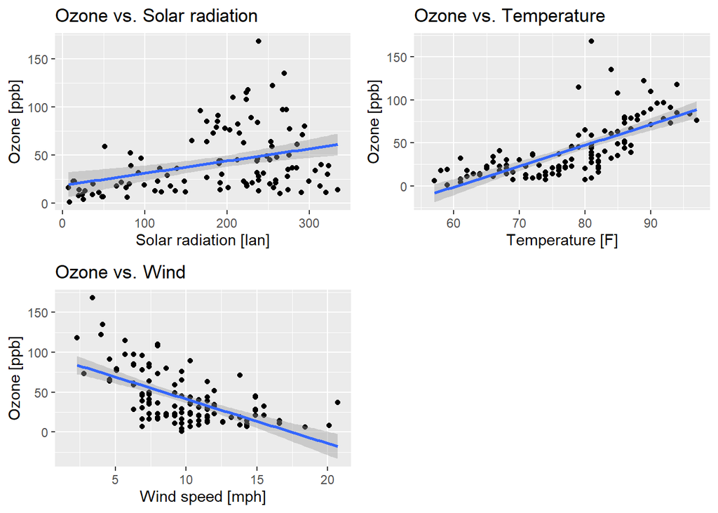

```r
#plot ozone against solar radiation
oz_sol <- ggplot(data = airquality, aes(x = Solar.R, y = Ozone)) +
  geom_point() +
  geom_smooth(method = "lm") +
  labs(title = "Ozone vs. Solar radiation",
       x = "Solar radiation [lan]",
       y = "Ozone [ppb]")

#plot ozone vs. temperature
oz_temp <- ggplot(data = airquality, aes(x = Temp, y = Ozone)) +
  geom_point() +
  geom_smooth(method = "lm") +
  labs(title = "Ozone vs. Temperature",
       x = "Temperature [F]",
       y = "Ozone [ppb]")

#plot ozone vs. wind
oz_wind <- ggplot(data = airquality, aes(x = Wind, y = Ozone)) +
  geom_point() +
  geom_smooth(method = "lm") +
  labs(title = "Ozone vs. Wind",
       x = "Wind speed [mph]",
       y = "Ozone [ppb]")

#combine all plots and display them together
cowplot::plot_grid(oz_sol, oz_temp, oz_wind)
```

In the plot above, we see clearly that solar radiation has the weakest correlation with ozone concentration. To me, this comes as a surprise. I would have expected a stronger and (and negative) correlation, given that ozone absorbs UV-radiation. So I would have expected that a high concentration of ozone leads to less incoming solar radiation. A reason for this not being the case might be that the ozone data was not measured in the stratosphere (where the ozone layer is located) but rather in the same height as temperature and wind (a few meters above the ground on Roosevelt Island).